# Assessment 1

Christopher Schmidt S4532362

27/08/2021

# RMarkdown editing

**R Markdown** contains a combination of markdown (*content with simple text formatting*) and R code chunks.

R Markdown documents allow you to weave together narrative text and code to produce elegantly formatted output in dozens of formats, such as HTML, PDF, and MS Word documents.

For more details on how to use R Markdown see [Markdown Basics](https://rmarkdown.rstudio.com/lesson-8.html)

This document was created with **R Markdown**.

```r
## install packages once via console using - install.packages("tidyverse")
library(tidyverse) # load tidyverse library
library(skimr)     # load skimr library
library(janitor)   # load janitor library
```

```r
library(ggplot2)   # load ggplot library
library(knitr)     # load knitr library
```

### 6. Insert an R chunk and create a dataset variable called `fastfood`

```r
fastfood <- readr::read_csv('https://raw.githubusercontent.com/rfordatascience/tidytuesday/master/data/2018/2018-09-04/fastfood_calories.csv')
```

```
## * `` -> ...1
```

### 7. Display the **first 10 rows** and **first 5 variables** of the `fastfood` dataset

```r
fastfood%>%head(10)                 # Display the first 10 rows of the dataset using head() function.
```

```
## # A tibble: 10 x 18
##     ...1 restaurant item            calories cal_fat total_fat sat_fat trans_fat
##    <dbl> <chr>      <chr>              <dbl>   <dbl>     <dbl>   <dbl>     <dbl>
##  1     1 Mcdonalds  Artisan Grille~      380      60         7       2       0
##  2     2 Mcdonalds  Single Bacon S~      840     410        45      17       1.5
##  3     3 Mcdonalds  Double Bacon S~     1130     600        67      27       3
##  4     4 Mcdonalds  Grilled Bacon ~      750     280        31      10       0.5
##  5     5 Mcdonalds  Crispy Bacon S~      920     410        45      12       0.5
##  6     6 Mcdonalds  Big Mac              540     250        28      10       1
##  7     7 Mcdonalds  Cheeseburger         300     100        12       5       0.5
##  8     8 Mcdonalds  Classic Chicke~      510     210        24       4       0
##  9     9 Mcdonalds  Double Cheeseb~      430     190        21      11       1
## 10    10 Mcdonalds  Double Quarter~      770     400        45      21       2.5
## # ... with 10 more variables: cholesterol <dbl>, sodium <dbl>,
## #   total_carb <dbl>, fiber <dbl>, sugar <dbl>, protein <dbl>, vit_a <dbl>,
## #   vit_c <dbl>, calcium <dbl>, salad <chr>
```

```r
kable((fastfood[1:10, 1:5])) # first 10 rows of the dataset and the first 5 variables using kabble() function
```

| …1 | restaurant | item | calories | cal_fat |
| --- | --- | --- | --- | --- |
| 1 | Mcdonalds | Artisan Grilled Chicken Sandwich | 380 | 60 |
| 2 | Mcdonalds | Single Bacon Smokehouse Burger | 840 | 410 |
| 3 | Mcdonalds | Double Bacon Smokehouse Burger | 1130 | 600 |
| 4 | Mcdonalds | Grilled Bacon Smokehouse Chicken Sandwich | 750 | 280 |
| 5 | Mcdonalds | Crispy Bacon Smokehouse Chicken Sandwich | 920 | 410 |
| 6 | Mcdonalds | Big Mac | 540 | 250 |
| 7 | Mcdonalds | Cheeseburger | 300 | 100 |
| 8 | Mcdonalds | Classic Chicken Sandwich | 510 | 210 |
| 9 | Mcdonalds | Double Cheeseburger | 430 | 190 |
| 10 | Mcdonalds | Double Quarter Pounder® with Cheese | 770 | 400 |

### 8. Display observations that have more than **1000 calories**

```r
fastfood%>%             # Pipe dataset into filter function
  filter(calories>1000) # Filter by calories greater than 1000
```

```
## # A tibble: 28 x 18
##     ...1 restaurant item            calories cal_fat total_fat sat_fat trans_fat
##    <dbl> <chr>      <chr>              <dbl>   <dbl>     <dbl>   <dbl>     <dbl>
##  1     3 Mcdonalds  Double Bacon S~     1130     600        67      27       3
##  2    38 Mcdonalds  10 piece Butte~     1210     630        70      12       1
##  3    39 Mcdonalds  12 piece Butte~     1510     790        88      15       1
##  4    40 Mcdonalds  20 piece Butte~     2430    1270       141      24       2
##  5    45 Mcdonalds  40 piece Chick~     1770     960       107      18       0.5
##  6    48 Mcdonalds  10 piece Sweet~     1600     600        66      10       0
##  7    99 Sonic      Super Sonic Ba~     1280     830        92      36       4
##  8   100 Sonic      Super Sonic Do~     1120     680        76      32       4
##  9   101 Sonic      Super Sonic Do~     1130     680        76      32       4
## 10   102 Sonic      Super Sonic Do~     1220     780        87      34       4
## # ... with 18 more rows, and 10 more variables: cholesterol <dbl>,
## #   sodium <dbl>, total_carb <dbl>, fiber <dbl>, sugar <dbl>, protein <dbl>,
## #   vit_a <dbl>, vit_c <dbl>, calcium <dbl>, salad <chr>
```

### 9. Save observations with more than **40 in total_fat** and more than **80 in total_carb** in a new variable called `dont_eat_this`

```r
dont_eat_this <- fastfood%>%           # Create new variable called `dont_eat_this` and assign filtered dataset to it
  filter(total_fat>40 & total_carb>80) # filter by total_fat greater than 40 & total_carb greatre than 80
```

### 10. Using the initial dataset variable, display observations from restaurant **Mcdonalds**

```r
fastfood%>%                       # Pipe dataset into filter function
  filter(restaurant=="Mcdonalds") # Filter by restaurant named Mcdonalds
```

```
## # A tibble: 57 x 18
##     ...1 restaurant item            calories cal_fat total_fat sat_fat trans_fat
##    <dbl> <chr>      <chr>              <dbl>   <dbl>     <dbl>   <dbl>     <dbl>
##  1     1 Mcdonalds  Artisan Grille~      380      60         7       2       0
##  2     2 Mcdonalds  Single Bacon S~      840     410        45      17       1.5
##  3     3 Mcdonalds  Double Bacon S~     1130     600        67      27       3
##  4     4 Mcdonalds  Grilled Bacon ~      750     280        31      10       0.5
##  5     5 Mcdonalds  Crispy Bacon S~      920     410        45      12       0.5
##  6     6 Mcdonalds  Big Mac              540     250        28      10       1
##  7     7 Mcdonalds  Cheeseburger         300     100        12       5       0.5
##  8     8 Mcdonalds  Classic Chicke~      510     210        24       4       0
##  9     9 Mcdonalds  Double Cheeseb~      430     190        21      11       1
## 10    10 Mcdonalds  Double Quarter~      770     400        45      21       2.5
## # ... with 47 more rows, and 10 more variables: cholesterol <dbl>,
## #   sodium <dbl>, total_carb <dbl>, fiber <dbl>, sugar <dbl>, protein <dbl>,
## #   vit_a <dbl>, vit_c <dbl>, calcium <dbl>, salad <chr>
```

## Part 2

### 11. Display the types of variables in the dataset using `skimr` package

```r
#skim(fastfood)
fastfood %>%
  skim() # Pipe dataset into skim function
```

Data summary

| Name | Piped data |
| --- | --- |
| Number of rows | 515 |
| Number of columns | 18 |
| _______________________ |  |
| Column type frequency: |  |
| character | 3 |
| numeric | 15 |
| ________________________ |  |
| Group variables | None |

**Variable type: character**

| skim_variable | n_missing | complete_rate | min | max | empty | n_unique | whitespace |
| --- | --- | --- | --- | --- | --- | --- | --- |
| restaurant | 0 | 1 | 5 | 11 | 0 | 8 | 0 |
| item | 0 | 1 | 5 | 63 | 0 | 505 | 0 |
| salad | 0 | 1 | 5 | 5 | 0 | 1 | 0 |

**Variable type: numeric**

| skim_variable | n_missing | complete_rate | mean | sd | p0 | p25 | p50 | p75 | p100 | hist |
| --- | --- | --- | --- | --- | --- | --- | --- | --- | --- | --- |
| …1 | 0 | 1.00 | 258.00 | 148.81 | 1 | 129.5 | 258.0 | 386.5 | 515 | ▇▇▇▇▇ |
| calories | 0 | 1.00 | 530.91 | 282.44 | 20 | 330.0 | 490.0 | 690.0 | 2430 | ▇▆▁▁▁ |
| cal_fat | 0 | 1.00 | 238.81 | 166.41 | 0 | 120.0 | 210.0 | 310.0 | 1270 | ▇▃▁▁▁ |
| total_fat | 0 | 1.00 | 26.59 | 18.41 | 0 | 14.0 | 23.0 | 35.0 | 141 | ▇▃▁▁▁ |
| sat_fat | 0 | 1.00 | 8.15 | 6.42 | 0 | 4.0 | 7.0 | 11.0 | 47 | ▇▃▁▁▁ |
| trans_fat | 0 | 1.00 | 0.47 | 0.84 | 0 | 0.0 | 0.0 | 1.0 | 8 | ▇▁▁▁▁ |
| cholesterol | 0 | 1.00 | 72.46 | 63.16 | 0 | 35.0 | 60.0 | 95.0 | 805 | ▇▁▁▁▁ |
| sodium | 0 | 1.00 | 1246.74 | 689.95 | 15 | 800.0 | 1110.0 | 1550.0 | 6080 | ▇▆▁▁▁ |
| total_carb | 0 | 1.00 | 45.66 | 24.88 | 0 | 28.5 | 44.0 | 57.0 | 156 | ▅▇▂▁▁ |
| fiber | 12 | 0.98 | 4.14 | 3.04 | 0 | 2.0 | 3.0 | 5.0 | 17 | ▇▅▂▁▁ |
| sugar | 0 | 1.00 | 7.26 | 6.76 | 0 | 3.0 | 6.0 | 9.0 | 87 | ▇▁▁▁▁ |
| protein | 1 | 1.00 | 27.89 | 17.68 | 1 | 16.0 | 24.5 | 36.0 | 186 | ▇▂▁▁▁ |
| vit_a | 214 | 0.58 | 18.86 | 31.38 | 0 | 4.0 | 10.0 | 20.0 | 180 | ▇▁▁▁▁ |
| vit_c | 210 | 0.59 | 20.17 | 30.59 | 0 | 4.0 | 10.0 | 30.0 | 400 | ▇▁▁▁▁ |
| calcium | 210 | 0.59 | 24.85 | 25.52 | 0 | 8.0 | 20.0 | 30.0 | 290 | ▇▁▁▁▁ |

### 12. Show the `count` of observations for each restaurant.

```r
fastfood %>%
  count(restaurant) # Pipe dataset into count function and count restaurants.
```

```
## # A tibble: 8 x 2
##   restaurant      n
##   <chr>       <int>
## 1 Arbys          55
## 2 Burger King    70
## 3 Chick Fil-A    27
## 4 Dairy Queen    42
## 5 Mcdonalds      57
## 6 Sonic          53
## 7 Subway         96
## 8 Taco Bell     115
```

### 13. Using grouppings `group_by()`, summarise and display the average number of calories for each restaurant.

```r
fastfood %>%
  group_by(restaurant) %>% # Pipe dataset into group_by function and group by restaurant
  summarise(calories=mean(calories)) # Pipe dataset into summarise function and use mean function to get avg calories
```

```
## # A tibble: 8 x 2
##   restaurant  calories
##   <chr>          <dbl>
## 1 Arbys           533.
## 2 Burger King     609.
## 3 Chick Fil-A     384.
## 4 Dairy Queen     520.
## 5 Mcdonalds       640.
## 6 Sonic           632.
## 7 Subway          503.
## 8 Taco Bell       444.
```

### 14. Add a variable to the dataset, which calculates the average calories per type of restaurant and call it `average_calories`

```r
fastfood <- fastfood %>%
  group_by(restaurant) %>% # Pipe dataset into group_by function and group by restaurant
  mutate(average_calories=mean(calories)) #Pipe into mutate function to create new variable, use mean function to get avg calories
```

### 15. Display the data vis of total fat per each type of restaurant

#### Observations

gemo_col was used as we have one discrete and one continuous Chick Fil-A has the lowest total fat Burger King has the highest total fat

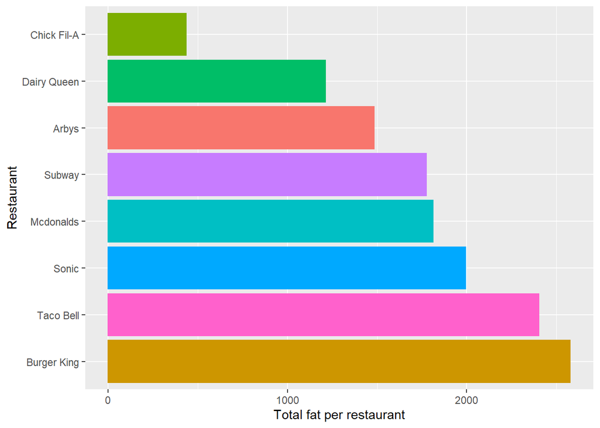

```r
fastfood%>%
  group_by(restaurant)%>% # Pipe dataset into group_by function and group by restaurant
  summarise(restaurant_fat=sum(total_fat))%>% # Pipe dataset into summarise function and use sum function to get total fat
  ggplot(aes(reorder(restaurant, -restaurant_fat),restaurant_fat,color=restaurant,fill=restaurant))+ #use ggplot and reorder by fat
  geom_col()+ # add Bar charts using geom_col
  labs(x = "Restaurant", y = "Total fat per restaurant")+ #add label to the plot
  coord_flip()+ # change postion of X and Y coords
  theme(legend.position = "none") # remove the legend
```

### 16. Add a variable to the dataset, which calculates the maximum total fat per type of restaurant and call it `max_total_fat`

```r
fastfood<-fastfood %>%  # write back to dataset
  group_by(restaurant)%>% # Pipe dataset into group_by function and group by restaurant
  mutate(max_total_fat=max(total_fat)) #Pipe into mutate function to create new variable, use max fuction to get max fat
```

### 17. Use observations for Mcdonalds to plot sugar variable against protein with `geom_point()`

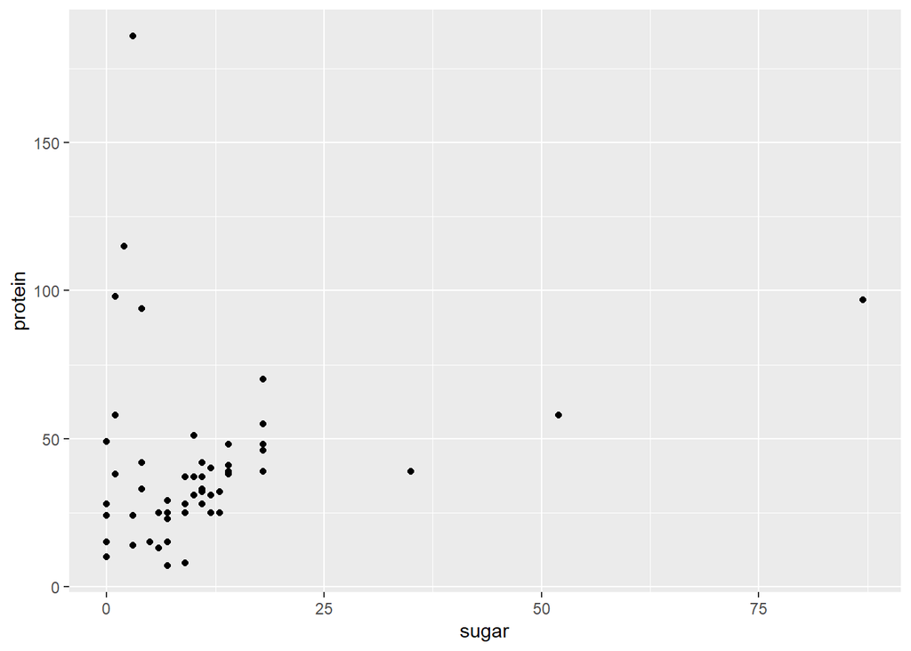

```r
fastfood%>%
  filter(restaurant=="Mcdonalds") %>% # Pipe dataset into filter function and select Mcdonalds
  ggplot(aes(sugar,protein))+ # use ggplot to plot sugar variable against protein
  geom_point() # Pipe into geom_point to create scatterplots
```

### PART 3

### 18. Identify variable(s) which should be factors and transform their type into a factor variable.

```r
names(fastfood) #investigate dataset using names function
```

```
##  [1] "...1"             "restaurant"       "item"             "calories"
##  [5] "cal_fat"          "total_fat"        "sat_fat"          "trans_fat"
##  [9] "cholesterol"      "sodium"           "total_carb"       "fiber"
## [13] "sugar"            "protein"          "vit_a"            "vit_c"
## [17] "calcium"          "salad"            "average_calories" "max_total_fat"
```

```r
fastfood <- fastfood %>% # Pipe dataset into mutate
  mutate(restaurant=as_factor(restaurant)) #convert restaurant to a factor

fastfood %>% head() #check to see if restaurant has been converted to a factor
```

```
## # A tibble: 6 x 20
## # Groups:   restaurant [1]
##    ...1 restaurant item             calories cal_fat total_fat sat_fat trans_fat
##   <dbl> <fct>      <chr>               <dbl>   <dbl>     <dbl>   <dbl>     <dbl>
## 1     1 Mcdonalds  Artisan Grilled~      380      60         7       2       0
## 2     2 Mcdonalds  Single Bacon Sm~      840     410        45      17       1.5
## 3     3 Mcdonalds  Double Bacon Sm~     1130     600        67      27       3
## 4     4 Mcdonalds  Grilled Bacon S~      750     280        31      10       0.5
## 5     5 Mcdonalds  Crispy Bacon Sm~      920     410        45      12       0.5
## 6     6 Mcdonalds  Big Mac               540     250        28      10       1
## # ... with 12 more variables: cholesterol <dbl>, sodium <dbl>,
## #   total_carb <dbl>, fiber <dbl>, sugar <dbl>, protein <dbl>, vit_a <dbl>,
## #   vit_c <dbl>, calcium <dbl>, salad <chr>, average_calories <dbl>,
## #   max_total_fat <dbl>
```

### 19. Create two new variables: add a new variable to the dataset `calories_type`

### Use `calories` variable for `cut_number()` function to split it into 3 categories `n=3`, add labels `labels=c("low", "med", "high")` and make the dataset ordered.

```r
fastfood <- fastfood %>% # Pipe dataset into mutate
  mutate(calories_type = cut_number(calories, n=3, labels=c("low", "med", "high"))) %>% #use cut_ restaurant to a factor
  arrange(calories) #make dataset ordered using arrange by calories
```

### 20. Display the dataviz of shows the distribution of `calories_type` in food items for each type of restaurant.

### Use facets, coordinates and theme layers to make your data viz visually appealing and meaningful.

### Use factors related data viz functions

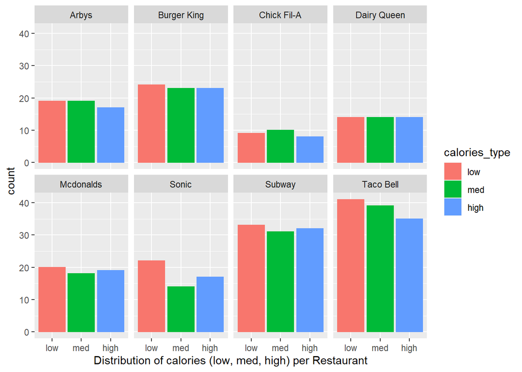

```r
fastfood %>% # Pipe dataset into ggplot
  ggplot(aes(calories_type,color=calories_type,fill = calories_type))+ # use ggplot to plot calories_type by restaurant
  geom_bar()+ # add Bar charts using geom_bar
  facet_wrap(vars(restaurant), ncol = 4)+ # use function facet_wrap to create a plot for each restaurant
  labs(x = "Distribution of calories (low, med, high) per Restaurant") #add label to the plot
```

### 21. Add the variable to the dataset and call it `trans_fat_percent`

### `trans_fat_percent` equals the percentage of `trans_fat` in `total_fat`

```r
fastfood <- fastfood %>%
  mutate(trans_fat_percent = trans_fat/total_fat*100) # Pipe into mutate to create new variable, use trans_fat/total_fat*100
```

### 22. Display the dataviz of shows the distribution of `trans_fat` in food items for each type of restaurant.

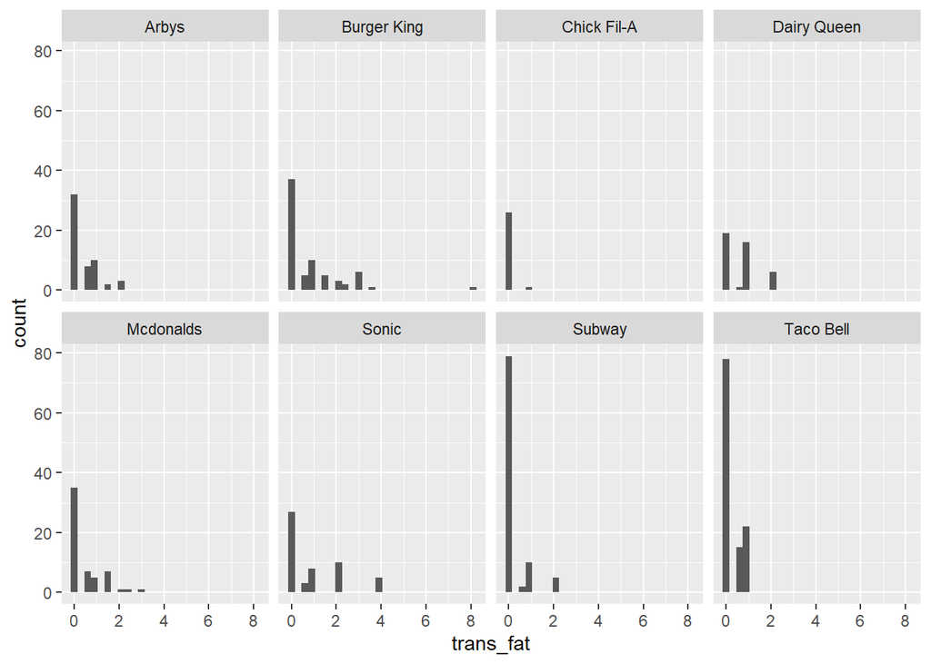

```r
fastfood %>%
  ggplot(aes(trans_fat))+  # use ggplot to plot trans_fat
  geom_histogram(binwidth = 0.3)+ # add histogram using geom_histogram
  facet_wrap(vars(restaurant), ncol = 4) # use function facet_wrap to create a plot for each restaurant
```

### 23. Calculate and show the average (mean) `total_fat` for each type of restaurant.

```r
fastfood %>%
  group_by(restaurant)%>% # Pipe dataset into group_by function and group by restaurant
  summarise(total_fat=mean(total_fat)) # Pipe into summarise function and use mean function to show average total fat
```

```
## # A tibble: 8 x 2
##   restaurant  total_fat
##   <fct>           <dbl>
## 1 Arbys            27.0
## 2 Burger King      36.8
## 3 Chick Fil-A      16.1
## 4 Dairy Queen      28.9
## 5 Mcdonalds        31.8
## 6 Sonic            37.6
## 7 Subway           18.5
## 8 Taco Bell        20.9
```

### 24. Create a dataviz that allow to compare different restaurants on this variable `total_fat`.

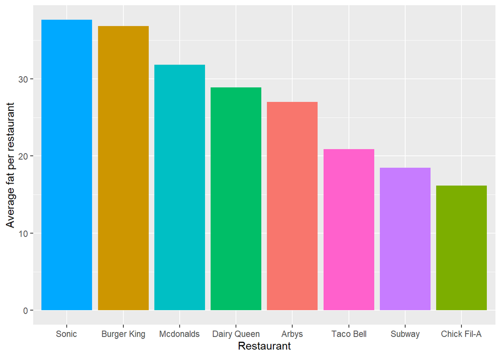

```r
fastfood %>%
  group_by(restaurant)%>% # Pipe dataset into group_by function and group by restaurant
  summarise(restaurant_fat=mean(total_fat))%>% # Pipe into summarise function and use mean function to show average total fat
  ggplot(aes(reorder(restaurant, -restaurant_fat),restaurant_fat, fill=restaurant))+ # use ggplot to plot fat by restaurant
  geom_col()+ # add Bar charts using geom_col
  labs(x = "Restaurant", y = "Average fat per restaurant")+ # #add label to the plot
  theme(legend.position = "none") # remove the legend
```